```python
from matplotlib import pyplot as plt
from mpl_toolkits.mplot3d import Axes3D
from mpl_toolkits.axes_grid1 import make_axes_locatable
import IPython.display as ipd
import numpy as np
%matplotlib notebook
from scipy.signal import lfilter
```

ploting 위해 필요한 lib들 가져옴 matplotlib -> 가장 큰 lib **같은 역할을 하는 것 eg) import matplotlib.pyplot = from matplotlib import pyplot

# Phasor

```python
# parameter setting
amp = 2         #range [0.0,1.0]
sr = 10000      # sampling rate, Hz / 벡터(점들)의 양 / 1초동안 점들의 개수
dur = 0.5       # in seconds
freq = 200.0     # sine frequency, Hz / 1초 동안 몇번 반복되는가
```

각도값만으로 곡선 만들 수 없기 때문에 sine 불러옴

time의 해상도 10000으로 맞춰주기

t 0.0001 0.0002 0.0003 ... 0.5000

t 5000개 생성 e-04 = 1/10000

```python
theta = np.arange(0, 2*np.pi,0.1)
theta
```

```
array([0. , 0.1, 0.2, 0.3, 0.4, 0.5, 0.6, 0.7, 0.8, 0.9, 1. , 1.1, 1.2,
       1.3, 1.4, 1.5, 1.6, 1.7, 1.8, 1.9, 2. , 2.1, 2.2, 2.3, 2.4, 2.5,
       2.6, 2.7, 2.8, 2.9, 3. , 3.1, 3.2, 3.3, 3.4, 3.5, 3.6, 3.7, 3.8,
       3.9, 4. , 4.1, 4.2, 4.3, 4.4, 4.5, 4.6, 4.7, 4.8, 4.9, 5. , 5.1,
       5.2, 5.3, 5.4, 5.5, 5.6, 5.7, 5.8, 5.9, 6. , 6.1, 6.2])
```

theta 범위 정함

sin 함수 np 속에 들어있음

```python
s = np.sin(theta)
s
```

```
array([ 0.        ,  0.09983342,  0.19866933,  0.29552021,  0.38941834,
        0.47942554,  0.56464247,  0.64421769,  0.71735609,  0.78332691,
        0.84147098,  0.89120736,  0.93203909,  0.96355819,  0.98544973,
        0.99749499,  0.9995736 ,  0.99166481,  0.97384763,  0.94630009,
        0.90929743,  0.86320937,  0.8084964 ,  0.74570521,  0.67546318,
        0.59847214,  0.51550137,  0.42737988,  0.33498815,  0.23924933,
        0.14112001,  0.04158066, -0.05837414, -0.15774569, -0.2555411 ,
       -0.35078323, -0.44252044, -0.52983614, -0.61185789, -0.68776616,
       -0.7568025 , -0.81827711, -0.87157577, -0.91616594, -0.95160207,
       -0.97753012, -0.993691  , -0.99992326, -0.99616461, -0.98245261,
       -0.95892427, -0.92581468, -0.88345466, -0.83226744, -0.77276449,
       -0.70554033, -0.63126664, -0.55068554, -0.46460218, -0.37387666,
       -0.2794155 , -0.1821625 , -0.0830894 ])
```

figure = 화면 전체 221 = 2x2 의 1번째 221,222,223,224 -> 같은 그래프 4개(2x2)

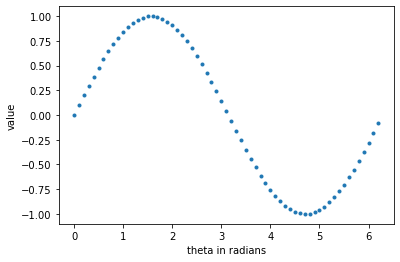

```python
fig=plt.figure()
ax=fig.add_subplot(111)
ax.plot(theta,s,'.')
ax.set_xlabel('theta in radians')
ax.set_ylabel('value')
```

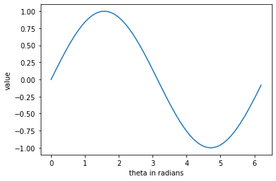

```python
fig=plt.figure()
ax=fig.add_subplot(111)
ax.plot(theta,s,'-')
ax.set_xlabel('theta in radians')
ax.set_ylabel('value')
```

디폴트 -> '-'

0 ~ 파이 ~ 2파이(약 6.28) **x값들 사이의 거리 - 일정/ y값들 사이의 거리 - 일정x -> not linear**y축도 일정 <- linear(직선인) 할 때 (y=ax+b) -> 1차 함수 아닌 모든 함수는 linear 하지 않음

```python
theta = np.arange(0, 2*np.pi*5,0.1)
theta
```

```
array([ 0. ,  0.1,  0.2,  0.3,  0.4,  0.5,  0.6,  0.7,  0.8,  0.9,  1. ,
        1.1,  1.2,  1.3,  1.4,  1.5,  1.6,  1.7,  1.8,  1.9,  2. ,  2.1,
        2.2,  2.3,  2.4,  2.5,  2.6,  2.7,  2.8,  2.9,  3. ,  3.1,  3.2,
        3.3,  3.4,  3.5,  3.6,  3.7,  3.8,  3.9,  4. ,  4.1,  4.2,  4.3,
        4.4,  4.5,  4.6,  4.7,  4.8,  4.9,  5. ,  5.1,  5.2,  5.3,  5.4,
        5.5,  5.6,  5.7,  5.8,  5.9,  6. ,  6.1,  6.2,  6.3,  6.4,  6.5,
        6.6,  6.7,  6.8,  6.9,  7. ,  7.1,  7.2,  7.3,  7.4,  7.5,  7.6,
        7.7,  7.8,  7.9,  8. ,  8.1,  8.2,  8.3,  8.4,  8.5,  8.6,  8.7,
        8.8,  8.9,  9. ,  9.1,  9.2,  9.3,  9.4,  9.5,  9.6,  9.7,  9.8,
        9.9, 10. , 10.1, 10.2, 10.3, 10.4, 10.5, 10.6, 10.7, 10.8, 10.9,
       11. , 11.1, 11.2, 11.3, 11.4, 11.5, 11.6, 11.7, 11.8, 11.9, 12. ,
       12.1, 12.2, 12.3, 12.4, 12.5, 12.6, 12.7, 12.8, 12.9, 13. , 13.1,
       13.2, 13.3, 13.4, 13.5, 13.6, 13.7, 13.8, 13.9, 14. , 14.1, 14.2,
       14.3, 14.4, 14.5, 14.6, 14.7, 14.8, 14.9, 15. , 15.1, 15.2, 15.3,
       15.4, 15.5, 15.6, 15.7, 15.8, 15.9, 16. , 16.1, 16.2, 16.3, 16.4,
       16.5, 16.6, 16.7, 16.8, 16.9, 17. , 17.1, 17.2, 17.3, 17.4, 17.5,
       17.6, 17.7, 17.8, 17.9, 18. , 18.1, 18.2, 18.3, 18.4, 18.5, 18.6,
       18.7, 18.8, 18.9, 19. , 19.1, 19.2, 19.3, 19.4, 19.5, 19.6, 19.7,
       19.8, 19.9, 20. , 20.1, 20.2, 20.3, 20.4, 20.5, 20.6, 20.7, 20.8,
       20.9, 21. , 21.1, 21.2, 21.3, 21.4, 21.5, 21.6, 21.7, 21.8, 21.9,
       22. , 22.1, 22.2, 22.3, 22.4, 22.5, 22.6, 22.7, 22.8, 22.9, 23. ,
       23.1, 23.2, 23.3, 23.4, 23.5, 23.6, 23.7, 23.8, 23.9, 24. , 24.1,
       24.2, 24.3, 24.4, 24.5, 24.6, 24.7, 24.8, 24.9, 25. , 25.1, 25.2,
       25.3, 25.4, 25.5, 25.6, 25.7, 25.8, 25.9, 26. , 26.1, 26.2, 26.3,
       26.4, 26.5, 26.6, 26.7, 26.8, 26.9, 27. , 27.1, 27.2, 27.3, 27.4,
       27.5, 27.6, 27.7, 27.8, 27.9, 28. , 28.1, 28.2, 28.3, 28.4, 28.5,
       28.6, 28.7, 28.8, 28.9, 29. , 29.1, 29.2, 29.3, 29.4, 29.5, 29.6,
       29.7, 29.8, 29.9, 30. , 30.1, 30.2, 30.3, 30.4, 30.5, 30.6, 30.7,
       30.8, 30.9, 31. , 31.1, 31.2, 31.3, 31.4])
```

```python
# generate signal by cosine-phasor
s = amp*np.sin(theta) # 진폭x2
```

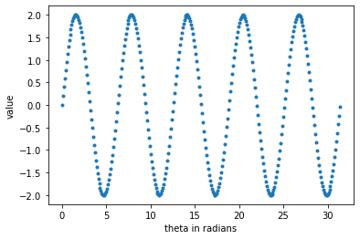

```python
fig=plt.figure()
ax=fig.add_subplot(111)
ax.plot(theta,s,'.')
ax.set_xlabel('theta in radians')
ax.set_ylabel('value')
```

그래프 5번 반복

소리 -> 시간 있어야함

```python
# generate time
t = np.arange(1,sr*dur+1)/sr
```

```python
# generate phase / time 입히는 단계
theta = t*2*np.pi*freq
# 1초 동안 한바퀴 도는 것을 만들어라(t*2*np.pi) + 바퀴에 해당하는 것 곱하기(freq)
```

```python
# generate signal by cosine-phasor
s=amp*np.sin(theta)
s
```

```
array([ 2.50666467e-01,  4.97379774e-01,  7.36249105e-01, ...,
       -4.97379774e-01, -2.50666467e-01,  7.85754689e-15])
```

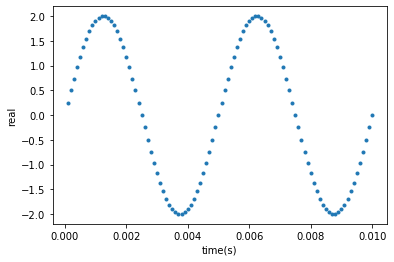

```python
fig=plt.figure()
ax=fig.add_subplot(111)
ax.plot(t[0:100],s[0:100],'.')
ax.set_xlabel('time(s)')
ax.set_ylabel('real')

# 위에서 amp(2)곱하니까 진폭 2로 바뀜 (진폭을 phasor에 심을 수 있음)
```

t와 theta에 같은 개수 벡터 들어있음

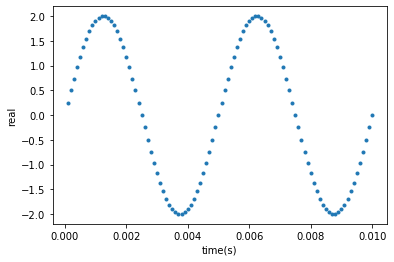

```python
fig=plt.figure()
ax=fig.add_subplot(111)
ax.plot(t[0:100],s[0:100],'.')
ax.set_xlabel('time(s)')
ax.set_ylabel('real')
```

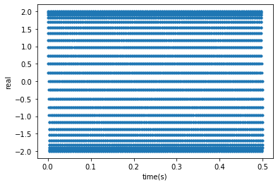

```python
fig=plt.figure()
ax=fig.add_subplot(111)
ax.plot(t,s,'.')
ax.set_xlabel('time(s)')
ax.set_ylabel('real')
```

```python
# generate signal by complex-phasor
c=amp*np.exp(theta*1j) #amp(진폭=2) 곱함
c
```

```
array([1.9842294 +2.50666467e-01j, 1.93716632+4.97379774e-01j,
       1.85955297+7.36249105e-01j, ..., 1.93716632-4.97379774e-01j,
       1.9842294 -2.50666467e-01j, 2.        +7.85754689e-15j])
```

np.exp=e. 1j=i complex number(복소수)의 데이터 늘어서있음 모두 a+bi 형태 -01, -02 .. -> 지수 -> 소수점의 위치와 관련 (정보량을 갖게 맞추기 위하여)

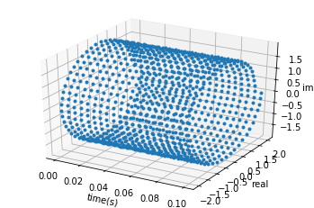

```python
fig=plt.figure()
ax=fig.add_subplot(111,projection='3d')
ax.plot(t[0:1000],c.real[0:1000],c.imag[0:1000],'.')
ax.set_xlabel('time(s)')
ax.set_ylabel('real')
ax.set_zlabel('imag')
```

amp=2=반지름 직경=4

점 총 1000개 찍힘 c.real -> 복소수의 실수부 가져옴 c.imag -> 복소수의 허수부 가져옴

<오일러 공식> cos -> 실수부와 관련 sin -> 허수부와 관련

```python
ipd.Audio(c.real, rate=sr)
```

[interactive chart not shown]

sr: 10000이라고 이전에 정의

```python
# !pip install sounddevice
import sounddevice as sd
sd.play(c.real,sr)
```

왜 수업과 달리 점이 1000개로 안 변하는지 11/12 보고 알아내기

# Generate pulse train

if sr=100Hz (우리가 표현할 수 있는 수가 1초에 100개) 1Hz를 한 번의 sine 웨이브 주기로 표현 가능 2Hz를 두 번의 " 10000Hz를 1초동안 표현하려고 할 때 x sr이 충분히 있어야지만 그만큼의 주파수를 표현 가능

주어진 벡터에 비해 표현할 수 있는 주파수는 max 1/2 max Hz = 1/2 Hz -> Nyquist Frequency

Sr = 44100 (인간이 들을 수 있는 범위가 약 20000Hz까지이기 때문/frequency >20000은 초음파) -> Nyquist Frequency = 22050 Hz (높은 소리까지 구현 가능)

sr/2 = Nyquist Frequency int는 지저분하지 않게 하기 위하여

harmonics 쌓음 (1~5000개)

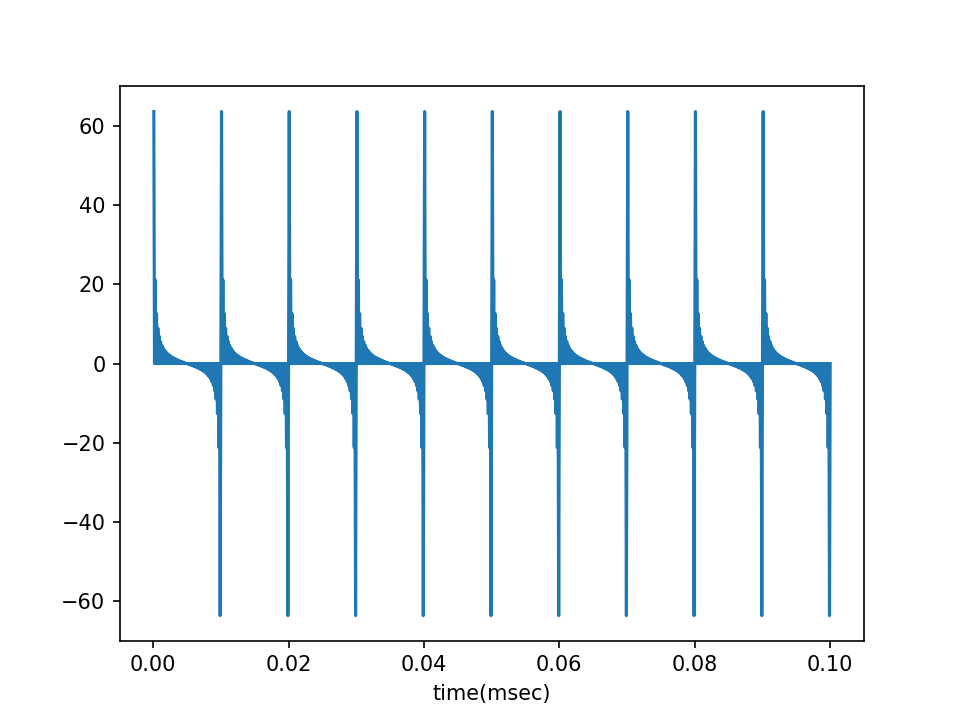

[interactive chart not shown]

```python
# generate samples, note conversion to float32 array
F0 = 100; Fend = int(sr/2); s=np.zeros(len(t));
for freq in range(F0, Fend+1, F0): # +는 마지막 것을 포함하기 위해 (50번 정도 돎)
    theta = t*2*np.pi*freq
    tmp=amp*np.sin(theta) # (=) s = s+amp+np.sin(theta)
    s=s+tmp
fig = plt.figure()
ax = fig.add_subplot(111)
ax.plot(t[0:1000], s[0:1000]);
ax.set_xlabel('time(msec)')
ipd.Audio(s,rate=sr)
```

spectrum은 x -> 점점 감소하도록 만들어야함

```python
# parameter setting
amp=1            #range [0.0, 1.0]
sr = 10000       #sampling rate, Hz
dur = 0.5        #in seconds
freq=440.0       #sine frequency, Hz
```

```python
# generate time
t=np.arange(1, sr*dur+1)/sr
```

```python
# generate phase(각도)
theta = t*2*np.pi*freq
```

```python
# generate signal by cosine-phasor
s=amp*np.cos(theta)
```

cos 그래프와 sine 그래프 시작하는 지점만 다름 pi/2 각도만 이동 -> 소리와는 관련x phase는 우리가 인식할 수x 인간은 frequency만 인식함

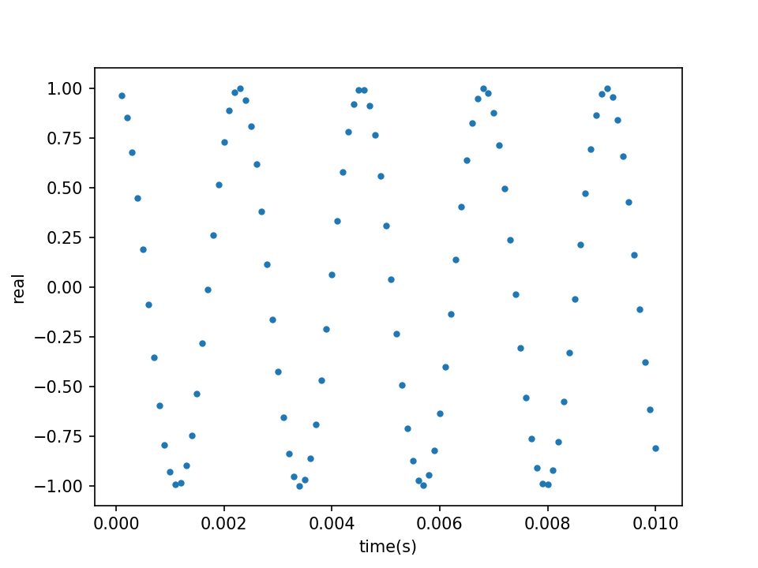

```python
fig=plt.figure()
ax=fig.add_subplot(111)
ax.plot(t[0:100], s[0:100], '.')
ax.set_xlabel('time(s)')
ax.set_ylabel('real')
```

```python
# generate signal by complex-phasor
c=amp+np.exp(theta*1j)
c
```

```
array([1.96202767+2.72951936e-01j, 1.85099448+5.25174630e-01j,
       1.67533281+7.37513117e-01j, ..., 1.85099448-5.25174630e-01j,
       1.96202767-2.72951936e-01j, 2.        +3.13806691e-14j])
```

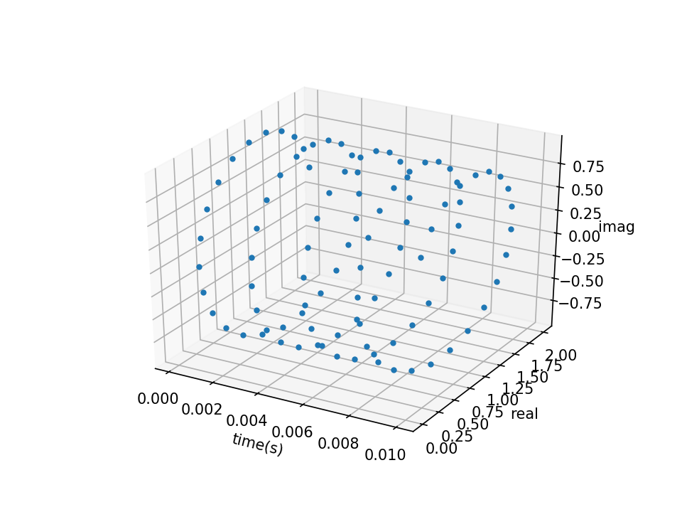

```python
fig = plt.figure()
ax = fig.add_subplot(111, projection='3d')
ax.plot(t[0:100], c.real[0:100], c.imag[0:100], '.')
ax.set_xlabel('time(s)')
ax.set_ylabel('real')
ax.set_zlabel('imag')
```

```python
ipd.Audio(s,rate=sr)
```

[interactive chart not shown]

```python
ipd.Audio(c.real,rate=sr)
```

[interactive chart not shown]

cos = c.real phasor sine = c.imag phasor

```python
def hz2w(F, sr):
    NyFreq = sr/2;
    w = F/NyFreq *np.pi;
    return w

def resonance (srate, F, BW):
    a2 = np.exp(-hz2w(BW,srate))
    omega = F*2*np.pi/srate
    a1 = -2*np.sqrt(a2)*np.cos(omega)
    a = np.array([1,a1,a2])
    b = np.array([sum(a)])
    return a, b
```

```python
RG = 0
BWG = 100
a, b = resonance(sr,RG,BWG)
s = lfilter(b, a, s, axis=0)
ipd.Audio(s, rate=sr)
```

[interactive chart not shown]

```python
RG = 500  # RG is the frequency of the Glottal Resonator
BWG = 60  # BWG is the bandwidth of the Glottal Resonator
a, b=resonance(sr,RG,BWG)
s = lfilter(b, a, s, axis=0)
ipd.Audio(s, rate=sr)
```

[interactive chart not shown]

```python
RG = 1500  # RG is the frequency of the Glottal Resonator
BWG = 200  # BWG is the bandwidth of the Glottal Resonator
a, b=resonance(sr,RG,BWG)
s = lfilter(b, a, s, axis=0)
ipd.Audio(s, rate=sr)
```

[interactive chart not shown]

```python
RG = 2500  # RG is the frequency of the Glottal Resonator
BWG = 200  # BWG is the bandwidth of the Glottal Resonator
a, b=resonance(sr,RG,BWG)
s = lfilter(b, a, s, axis=0)
ipd.Audio(s, rate=sr)
```

[interactive chart not shown]

```python
RG = 3500  # RG is the frequency of the Glottal Resonator
BWG = 200  # BWG is the bandwidth of the Glottal Resonator
a, b=resonance(sr,RG,BWG)
s = lfilter(b, a, s, axis=0)
ipd.Audio(s, rate=sr)
```

[interactive chart not shown]

입술 만들어주기

```python
s = lfilter(np.array([1, -1]), np.array([1]), s)
ipd.Audio(s, rate=sr)
```

[interactive chart not shown]

# load wav

```python
from scipy.io import wavfile
# sr, s = wavefile.read('a.wav')
nSamp = len(s)
dur = nSamp / sr
t = np.linspace(1/sr, dur, nSamp)
```

vector의 사이즈 -> 샘플 개수 중요 분석하려는 페이저 -> 타겟 페이저

# Fourier tranform

```python
nFFT = nSamp
amp = [];
for n in range(0,nFFT):
    omega = 2*np.pi*n/nFFT # angular velocity
    z = np.exp(omega*1j)**(np.arange(0,nSamp))
    amp.append(np.abs(np.dot(s,z)))
```

샘플 개수(n)만큼 루프 돎

[1 .... 100]x10000 / s [100 ... 10000] -> 100개

[figure not shown]

```python
# ploting
fig=plt.figure()
ax = fig.add_subplot(111)
freq=np.arange(1,nFFT+1)*sr/nFFT;
ax.plot(freq, amp)
ax.set_xlabel('frequency (Hz)')
ax.set_ylabel('amplitude')
```

**x축 0부터 10000까지 = 바의 개수 = sr의 개수

# Preprocessing signal

```python
max_freq = None  # cutoff freq
win_size = 0.008 # sec
win_step = 0.001  # sec
win_type = 'hanning' # options: 'rect', 'hamming', 'hanning', 'kaiser', 'blackman'
nfft = 1024

# Emphasize signal
s = preemphasis(s)
# Frame signal
frames = frame_signal(s, sr, win_size, win_step)
# Apply window function
frames *= get_window(win_size, sr, win_type)
print('frames:', frames.shape)
```

[output not shown]

어떻게 스펙트로그램은 연결되어있는가? 'win'통해 0.008초 만큼 + 0.001초만큼 이동

powspec = 1/nfft * (magspec**2) plot_spectrogram(powspec); 스펙트로그램의 진한 부분 > 1 " 연한 부분 < 1 -> 제곱해서 더욱 강조 (power spectrum) 절대로 마이너스는 안 나옴

```
         왜? 로그를 취하기 위해.
```

logspec = 10 * np.log10(magspec) # dB scale plot_spectrogram(logspec); -> 지수만 남아서 다루기 쉬운 범위의 수로 바뀜